# Count Data: Subgroup vs Population Method Comparison

Analysis

2025-12-04

# Overview

This document applies both the **population method** and the **subgroup method** to the first dataset from **scenario 2** of the count endpoint simulation, to verify that the calculations are correct.

## Load Libraries and Functions

```r
library(checkmate)
library(dplyr)
library(broom)
library(MASS) # For glm.nb
library(knitr)

# Source all helper functions
source("../functions.R")

# Set endpoint parameters (matching Subgroup.R)
endpoint_params <- list(
  folder = "Count",
  resp = "y",
  status = NULL,
  resptype = "count"
)
```

## Load Scenario 2 Data

```r
# Load scenario 2
scenario2 <- readRDS("Scenarios/scenario2.rds")

# Get the first dataset
df <- scenario2[[1]]

# Ensure arm is a factor
df$arm <- factor(df$arm)

# Show data structure
cat("Dataset dimensions:", nrow(df), "rows,", ncol(df), "columns\n")
```

```
## Dataset dimensions: 1000 rows, 13 columns
```

```r
cat("Arm levels:", levels(df$arm), "\n")
```

```
## Arm levels: 0 1
```

```r
cat("Table of arm:\n")
```

```
## Table of arm:
```

```r
print(table(df$arm))
```

```
##
##   0   1
## 500 500
```

```r
# Show first few rows
kable(head(df), caption = "First 6 rows of scenario 2, dataset 1")
```

First 6 rows of scenario 2, dataset 1

| id | arm | x_1 | x_2 | x_3 | x_4 | x_5 | x_6 | x_7 | x_8 | x_9 | x_10 | y |
| --- | --- | --- | --- | --- | --- | --- | --- | --- | --- | --- | --- | --- |
| 1 | 0 | b | a | b | b | d | b | b | c | b | c | 3 |
| 2 | 0 | b | b | a | a | d | a | a | b | a | c | 0 |
| 3 | 0 | a | a | b | c | a | b | b | a | b | c | 3 |
| 4 | 0 | a | a | a | c | a | b | b | c | b | c | 0 |
| 5 | 1 | b | a | b | c | d | b | b | c | b | c | 0 |
| 6 | 1 | a | b | b | c | a | a | a | c | a | a | 0 |

## Load Truth Data for Scenario 2

```r
# Load the count truth data
truth_file <- file.path("Scenarios", "truth.RData")

if (file.exists(truth_file)) {
  load(truth_file)

  cat("Truth data loaded successfully!\n")
  cat("\nTruth data structure:\n")
  print(names(simul_truth))

  # Extract scenario 2 truth
  truth_overall <- simul_truth$truth_overall
  truth_subgroup <- simul_truth$truth_subgroup

  # Filter for scenario 2
  truth_overall_s2 <- truth_overall[truth_overall$scenario == "2", ]
  truth_subgroup_s2 <- truth_subgroup[truth_subgroup$scenario == "2", ]

  cat("\nScenario 2 overall truth:\n")
  print(truth_overall_s2)

  cat("\nScenario 2 subgroup truth:\n")
  print(truth_subgroup_s2)

  cat("\n📝 SCENARIO 2 STRUCTURE:\n")
  cat("- Overall HR ≈ 0.66 (protective)\n")
  cat("- x_4=a: No treatment effect (HR ≈ 1.0)\n")
  cat("- x_4=b: Enhanced effect (HR ≈ 0.53)\n")
  cat("- x_4=c: Enhanced effect (HR ≈ 0.53)\n")
  cat("- All other subgroups: Same as overall (HR ≈ 0.66)\n\n")

  truth_available <- TRUE
} else {
  cat("WARNING: Truth data file not found at:", truth_file, "\n")
  cat("Run Truth.Rmd first to generate the truth data.\n")
  truth_available <- FALSE
}
```

[output not shown]

## Method 1: Population Method

The population method fits a single model to the entire dataset and replicates the estimate across all subgroups.

```r
# Apply the population method
simul_no <- 1

population_result <- population_method_endpoint(df, simul_no)

cat("\nPopulation method results:\n")
```

```
##
## Population method results:
```

```r
kable(population_result, caption = "Population Method Results")
```

Population Method Results

| simul_no | estimator | subgroup | estimate | std.error | lower_ci | upper_ci | p.value |
| --- | --- | --- | --- | --- | --- | --- | --- |
| 1 | population | S_1.a | -0.8661459 | 0.0756795 | -1.014475 | -0.7178168 | 0 |
| 1 | population | S_1.b | -0.8661459 | 0.0756795 | -1.014475 | -0.7178168 | 0 |
| 1 | population | S_2.a | -0.8661459 | 0.0756795 | -1.014475 | -0.7178168 | 0 |
| 1 | population | S_2.b | -0.8661459 | 0.0756795 | -1.014475 | -0.7178168 | 0 |
| 1 | population | S_3.a | -0.8661459 | 0.0756795 | -1.014475 | -0.7178168 | 0 |
| 1 | population | S_3.b | -0.8661459 | 0.0756795 | -1.014475 | -0.7178168 | 0 |
| 1 | population | S_4.a | -0.8661459 | 0.0756795 | -1.014475 | -0.7178168 | 0 |
| 1 | population | S_4.b | -0.8661459 | 0.0756795 | -1.014475 | -0.7178168 | 0 |
| 1 | population | S_4.c | -0.8661459 | 0.0756795 | -1.014475 | -0.7178168 | 0 |
| 1 | population | S_5.a | -0.8661459 | 0.0756795 | -1.014475 | -0.7178168 | 0 |
| 1 | population | S_5.b | -0.8661459 | 0.0756795 | -1.014475 | -0.7178168 | 0 |
| 1 | population | S_5.c | -0.8661459 | 0.0756795 | -1.014475 | -0.7178168 | 0 |
| 1 | population | S_5.d | -0.8661459 | 0.0756795 | -1.014475 | -0.7178168 | 0 |

```r
# Extract the unique estimate
unique_estimate <- unique(population_result$estimate)
cat("\nUnique population estimate (log-RR):", unique_estimate, "\n")
```

```
##
## Unique population estimate (log-RR): -0.8661459
```

```r
cat("Exponentiated (RR):", exp(unique_estimate), "\n")
```

```
## Exponentiated (RR): 0.4205693
```

### Verify Population Model Manually

```r
# Fit the model manually to verify
model_pop <- glm.nb(y ~ arm, data = df)

cat("\nManual population model summary:\n")
```

```
##
## Manual population model summary:
```

```r
print(summary(model_pop))
```

```
##
## Call:
## glm.nb(formula = y ~ arm, data = df, init.theta = 1.523396981,
##     link = log)
##
## Coefficients:
##             Estimate Std. Error z value Pr(>|z|)
## (Intercept)  0.77841    0.04723   16.48   <2e-16 ***
## arm1        -0.86615    0.07568  -11.45   <2e-16 ***
## ---
## Signif. codes:  0 '***' 0.001 '**' 0.01 '*' 0.05 '.' 0.1 ' ' 1
##
## (Dispersion parameter for Negative Binomial(1.5234) family taken to be 1)
##
##     Null deviance: 1196.2  on 999  degrees of freedom
## Residual deviance: 1061.7  on 998  degrees of freedom
## AIC: 3292.3
##
## Number of Fisher Scoring iterations: 1
##
##
##               Theta:  1.523
##           Std. Err.:  0.156
##
##  2 x log-likelihood:  -3286.341
```

```r
cat("\nManual estimate (log-RR):", coef(model_pop)[2], "\n")
```

```
##
## Manual estimate (log-RR): -0.8661459
```

```r
cat("Match with population_method_endpoint?",
    abs(coef(model_pop)[2] - unique_estimate) < 1e-6, "\n")
```

```
## Match with population_method_endpoint? TRUE
```

## Method 2: Subgroup Method

The subgroup method fits separate models within each subgroup.

```r
# Apply the subgroup method
subgroup_result <- subgroup_method_endpoint(df, simul_no)

cat("\nSubgroup method results:\n")
```

```
##
## Subgroup method results:
```

```r
kable(subgroup_result, caption = "Subgroup Method Results")
```

Subgroup Method Results

| simul_no | estimator | subgroup | estimate | std.error | lower_ci | upper_ci | p.value |
| --- | --- | --- | --- | --- | --- | --- | --- |
| 1 | subgroup | S_1.a | -0.6767464 | 0.1108918 | -0.8940943 | -0.4593985 | 0.00e+00 |
| 1 | subgroup | S_1.b | -1.0303419 | 0.1031181 | -1.2324535 | -0.8282303 | 0.00e+00 |
| 1 | subgroup | S_2.a | -0.8201332 | 0.1187417 | -1.0528669 | -0.5873996 | 0.00e+00 |
| 1 | subgroup | S_2.b | -0.8914675 | 0.0978236 | -1.0832017 | -0.6997333 | 0.00e+00 |
| 1 | subgroup | S_3.a | -0.9880430 | 0.1643696 | -1.3102075 | -0.6658785 | 0.00e+00 |
| 1 | subgroup | S_3.b | -0.8356439 | 0.0850812 | -1.0024030 | -0.6688848 | 0.00e+00 |
| 1 | subgroup | S_4.a | -0.5445276 | 0.1182159 | -0.7762307 | -0.3128245 | 4.10e-06 |
| 1 | subgroup | S_4.b | -1.1814718 | 0.1477935 | -1.4711471 | -0.8917964 | 0.00e+00 |
| 1 | subgroup | S_4.c | -1.0613453 | 0.1264194 | -1.3091274 | -0.8135632 | 0.00e+00 |
| 1 | subgroup | S_5.a | -0.8933717 | 0.2253288 | -1.3350162 | -0.4517273 | 7.35e-05 |
| 1 | subgroup | S_5.b | -0.8830795 | 0.2059612 | -1.2867633 | -0.4793956 | 1.81e-05 |
| 1 | subgroup | S_5.c | -0.9440491 | 0.1363971 | -1.2113874 | -0.6767108 | 0.00e+00 |
| 1 | subgroup | S_5.d | -0.8010291 | 0.1125314 | -1.0215906 | -0.5804677 | 0.00e+00 |

### Verify Subgroup Models Manually for x_4

Let’s manually fit models for the x_4 subgroups to verify the calculations.

```r
cat("\nManual verification for x_4 subgroups:\n\n")
```

```
##
## Manual verification for x_4 subgroups:
```

```r
for (level in levels(df$x_4)) {
  subdf <- df[df$x_4 == level, ]

  cat("Subgroup x_4 =", level, "\n")
  cat("  N =", nrow(subdf), "\n")
  cat("  Arm distribution:", table(subdf$arm), "\n")

  # Fit model
  model <- glm.nb(y ~ arm, data = subdf)

  # Extract coefficient
  coef_est <- coef(model)[2]
  se_est <- summary(model)$coefficients[2, "Std. Error"]

  cat("  Estimate (log-RR):", round(coef_est, 4), "\n")
  cat("  Std. Error:", round(se_est, 4), "\n")
  cat("  RR:", round(exp(coef_est), 4), "\n")

  # Compare to subgroup_result
  subg_name <- paste0("S_4.", level)
  matched_row <- subgroup_result[subgroup_result$subgroup == subg_name, ]

  if (nrow(matched_row) > 0) {
    cat("  Match with subgroup_method?",
        abs(matched_row$estimate - coef_est) < 1e-6, "\n")
  } else {
    cat("  WARNING: Subgroup", subg_name, "not found in results!\n")
  }

  cat("\n")
}
```

```
## Subgroup x_4 = a
##   N = 310
##   Arm distribution: 152 158
##   Estimate (log-RR): -0.5445
##   Std. Error: 0.1182
##   RR: 0.5801
##   Match with subgroup_method? TRUE
##
## Subgroup x_4 = b
##   N = 293
##   Arm distribution: 158 135
##   Estimate (log-RR): -1.1815
##   Std. Error: 0.1478
##   RR: 0.3068
##   Match with subgroup_method? TRUE
##
## Subgroup x_4 = c
##   N = 397
##   Arm distribution: 190 207
##   Estimate (log-RR): -1.0613
##   Std. Error: 0.1264
##   RR: 0.346
##   Match with subgroup_method? TRUE
```

### Verify Subgroup Models Manually for x_5

```r
cat("\nManual verification for x_5 subgroups:\n\n")
```

```
##
## Manual verification for x_5 subgroups:
```

```r
for (level in levels(df$x_5)) {
  subdf <- df[df$x_5 == level, ]

  cat("Subgroup x_5 =", level, "\n")
  cat("  N =", nrow(subdf), "\n")
  cat("  Arm distribution:", table(subdf$arm), "\n")

  # Fit model
  model <- glm.nb(y ~ arm, data = subdf)

  # Extract coefficient
  coef_est <- coef(model)[2]
  se_est <- summary(model)$coefficients[2, "Std. Error"]

  cat("  Estimate (log-RR):", round(coef_est, 4), "\n")
  cat("  Std. Error:", round(se_est, 4), "\n")
  cat("  RR:", round(exp(coef_est), 4), "\n")

  # Compare to subgroup_result
  subg_name <- paste0("S_5.", level)
  matched_row <- subgroup_result[subgroup_result$subgroup == subg_name, ]

  if (nrow(matched_row) > 0) {
    cat("  Match with subgroup_method?",
        abs(matched_row$estimate - coef_est) < 1e-6, "\n")
  } else {
    cat("  WARNING: Subgroup", subg_name, "not found in results!\n")
  }

  cat("\n")
}
```

```
## Subgroup x_5 = a
##   N = 159
##   Arm distribution: 76 83
##   Estimate (log-RR): -0.8934
##   Std. Error: 0.2253
##   RR: 0.4093
##   Match with subgroup_method? TRUE
##
## Subgroup x_5 = b
##   N = 127
##   Arm distribution: 68 59
##   Estimate (log-RR): -0.8831
##   Std. Error: 0.206
##   RR: 0.4135
##   Match with subgroup_method? TRUE
##
## Subgroup x_5 = c
##   N = 289
##   Arm distribution: 132 157
##   Estimate (log-RR): -0.944
##   Std. Error: 0.1364
##   RR: 0.389
##   Match with subgroup_method? TRUE
##
## Subgroup x_5 = d
##   N = 425
##   Arm distribution: 224 201
##   Estimate (log-RR): -0.801
##   Std. Error: 0.1125
##   RR: 0.4489
##   Match with subgroup_method? TRUE
```

## Comparison: Population vs Subgroup

```r
# Merge the two results for comparison
comparison <- merge(
  population_result[, c("subgroup", "estimate", "std.error")],
  subgroup_result[, c("subgroup", "estimate", "std.error")],
  by = "subgroup",
  suffixes = c("_pop", "_subg")
)

# Add difference column
comparison$diff <- comparison$estimate_subg - comparison$estimate_pop

# Show comparison
kable(comparison,
      digits = 4,
      caption = "Comparison: Population vs Subgroup Estimates")
```

Comparison: Population vs Subgroup Estimates

| subgroup | estimate_pop | std.error_pop | estimate_subg | std.error_subg | diff |
| --- | --- | --- | --- | --- | --- |
| S_1.a | -0.8661 | 0.0757 | -0.6767 | 0.1109 | 0.1894 |
| S_1.b | -0.8661 | 0.0757 | -1.0303 | 0.1031 | -0.1642 |
| S_2.a | -0.8661 | 0.0757 | -0.8201 | 0.1187 | 0.0460 |
| S_2.b | -0.8661 | 0.0757 | -0.8915 | 0.0978 | -0.0253 |
| S_3.a | -0.8661 | 0.0757 | -0.9880 | 0.1644 | -0.1219 |
| S_3.b | -0.8661 | 0.0757 | -0.8356 | 0.0851 | 0.0305 |
| S_4.a | -0.8661 | 0.0757 | -0.5445 | 0.1182 | 0.3216 |
| S_4.b | -0.8661 | 0.0757 | -1.1815 | 0.1478 | -0.3153 |
| S_4.c | -0.8661 | 0.0757 | -1.0613 | 0.1264 | -0.1952 |
| S_5.a | -0.8661 | 0.0757 | -0.8934 | 0.2253 | -0.0272 |
| S_5.b | -0.8661 | 0.0757 | -0.8831 | 0.2060 | -0.0169 |
| S_5.c | -0.8661 | 0.0757 | -0.9440 | 0.1364 | -0.0779 |
| S_5.d | -0.8661 | 0.0757 | -0.8010 | 0.1125 | 0.0651 |

```r
# Summary statistics
cat("\nDifference statistics (Subgroup - Population):\n")
```

```
##
## Difference statistics (Subgroup - Population):
```

```r
cat("Mean difference:", round(mean(comparison$diff), 4), "\n")
```

```
## Mean difference: -0.0224
```

```r
cat("Median difference:", round(median(comparison$diff), 4), "\n")
```

```
## Median difference: -0.0253
```

```r
cat("Range:", round(min(comparison$diff), 4), "to", round(max(comparison$diff), 4), "\n")
```

```
## Range: -0.3153 to 0.3216
```

```r
cat("SD of differences:", round(sd(comparison$diff), 4), "\n")
```

```
## SD of differences: 0.1651
```

## Visualization

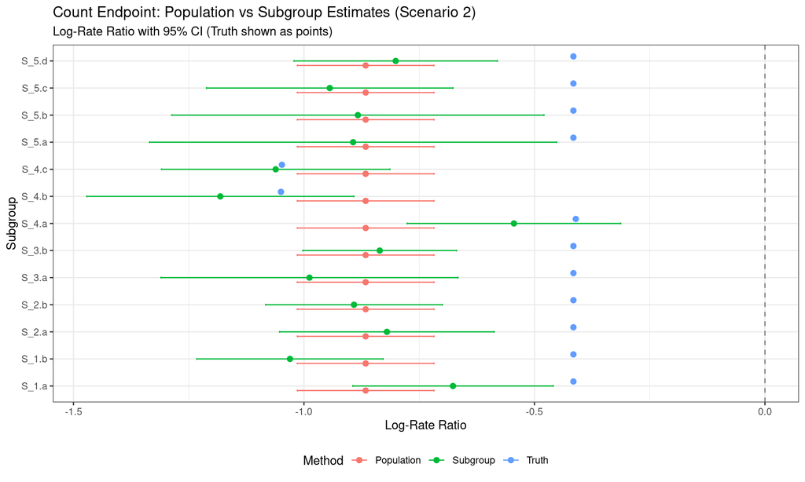

```r
library(ggplot2)

# Prepare data for plotting
plot_data <- rbind(
  data.frame(
    subgroup = population_result$subgroup,
    estimate = population_result$estimate,
    lower = population_result$lower_ci,
    upper = population_result$upper_ci,
    method = "Population"
  ),
  data.frame(
    subgroup = subgroup_result$subgroup,
    estimate = subgroup_result$estimate,
    lower = subgroup_result$lower_ci,
    upper = subgroup_result$upper_ci,
    method = "Subgroup"
  )
)

# Add truth data if available
if (truth_available) {
  truth_subgroup_s2$subgroup_clean <- gsub("^x_", "S_", truth_subgroup_s2$subgroup)

  truth_plot_data <- data.frame(
    subgroup = truth_subgroup_s2$subgroup_clean,
    estimate = truth_subgroup_s2$value,
    lower = NA,  # No CI for truth
    upper = NA,
    method = "Truth"
  )

  plot_data <- rbind(plot_data, truth_plot_data)
}

# Create forest plot
ggplot(plot_data, aes(x = estimate, y = subgroup, color = method)) +
  geom_point(position = position_dodge(width = 0.5), size = 2) +
  geom_errorbarh(aes(xmin = lower, xmax = upper),
                 position = position_dodge(width = 0.5),
                 height = 0.2) +
  geom_vline(xintercept = 0, linetype = "dashed", color = "gray50") +
  labs(
    title = "Count Endpoint: Population vs Subgroup Estimates (Scenario 2)",
    subtitle = "Log-Rate Ratio with 95% CI (Truth shown as points)",
    x = "Log-Rate Ratio",
    y = "Subgroup",
    color = "Method"
  ) +
  theme_bw() +
  theme(legend.position = "bottom")
```

## Expected vs Observed

For scenario 2, we expect: - x_4 subgroups to show heterogeneity - All other subgroups to be similar to the population average

```r
# For scenario 2, compare observed estimates to population and truth

cat("Observed POPULATION effect (average across all patients):\n")
```

```
## Observed POPULATION effect (average across all patients):
```

```r
pop_estimate <- unique(population_result$estimate)
cat(sprintf("  Log-RR: %.4f\n", pop_estimate))
```

```
##   Log-RR: -0.8661
```

```r
cat(sprintf("  RR: %.4f\n\n", exp(pop_estimate)))
```

```
##   RR: 0.4206
```

```r
cat("Observed SUBGROUP effects (separate models per subgroup):\n")
```

```
## Observed SUBGROUP effects (separate models per subgroup):
```

```r
for (i in 1:nrow(subgroup_result)) {
  diff_from_pop <- subgroup_result$estimate[i] - pop_estimate
  cat(sprintf("  %s: %.4f (RR = %.4f) [diff from pop: %+.4f]\n",
              subgroup_result$subgroup[i],
              subgroup_result$estimate[i],
              exp(subgroup_result$estimate[i]),
              diff_from_pop))
}
```

```
##   S_1.a: -0.6767 (RR = 0.5083) [diff from pop: +0.1894]
##   S_1.b: -1.0303 (RR = 0.3569) [diff from pop: -0.1642]
##   S_2.a: -0.8201 (RR = 0.4404) [diff from pop: +0.0460]
##   S_2.b: -0.8915 (RR = 0.4101) [diff from pop: -0.0253]
##   S_3.a: -0.9880 (RR = 0.3723) [diff from pop: -0.1219]
##   S_3.b: -0.8356 (RR = 0.4336) [diff from pop: +0.0305]
##   S_4.a: -0.5445 (RR = 0.5801) [diff from pop: +0.3216]
##   S_4.b: -1.1815 (RR = 0.3068) [diff from pop: -0.3153]
##   S_4.c: -1.0613 (RR = 0.3460) [diff from pop: -0.1952]
##   S_5.a: -0.8934 (RR = 0.4093) [diff from pop: -0.0272]
##   S_5.b: -0.8831 (RR = 0.4135) [diff from pop: -0.0169]
##   S_5.c: -0.9440 (RR = 0.3890) [diff from pop: -0.0779]
##   S_5.d: -0.8010 (RR = 0.4489) [diff from pop: +0.0651]
```

```r
cat("\n\nHeterogeneity summary:\n")
```

```
##
##
## Heterogeneity summary:
```

```r
cat(sprintf("  Range of subgroup effects: %.4f to %.4f\n",
            min(subgroup_result$estimate),
            max(subgroup_result$estimate)))
```

```
##   Range of subgroup effects: -1.1815 to -0.5445
```

```r
cat(sprintf("  SD of subgroup effects: %.4f\n",
            sd(subgroup_result$estimate)))
```

```
##   SD of subgroup effects: 0.1651
```

## Comparison with True Effects

Compare the observed estimates with the true treatment effects for scenario 2.

```r
if (truth_available) {

  # Prepare the truth data for comparison
  # Convert subgroup names to match our format (x_1.a -> S_1.a)
  truth_subgroup_s2$subgroup_clean <- gsub("^x_", "S_", truth_subgroup_s2$subgroup)

  # Merge with observed subgroup results
  comparison_truth <- merge(
    subgroup_result[, c("subgroup", "estimate")],
    truth_subgroup_s2[, c("subgroup_clean", "value")],
    by.x = "subgroup",
    by.y = "subgroup_clean",
    all.x = TRUE
  )

  names(comparison_truth) <- c("subgroup", "observed", "true")

  # Calculate bias (observed - true)
  comparison_truth$bias <- comparison_truth$observed - comparison_truth$true

  cat("\nComparison of Observed vs True Treatment Effects:\n")
  kable(comparison_truth,
        digits = 4,
        caption = "Observed vs True Log-RR (Scenario 2, Simulation 1)")

  # Summary statistics
  cat("\n\nBias summary (Observed - True):\n")
  cat(sprintf("  Mean bias: %.4f\n", mean(comparison_truth$bias, na.rm = TRUE)))
  cat(sprintf("  Median bias: %.4f\n", median(comparison_truth$bias, na.rm = TRUE)))
  cat(sprintf("  RMSE: %.4f\n", sqrt(mean(comparison_truth$bias^2, na.rm = TRUE))))
  cat(sprintf("  Range: %.4f to %.4f\n",
              min(comparison_truth$bias, na.rm = TRUE),
              max(comparison_truth$bias, na.rm = TRUE)))

  # Focus on x_4 subgroups
  cat("\n\n📊 X_4 SUBGROUPS (heterogeneity expected here):\n")
  x4_comparison <- comparison_truth[grepl("S_4", comparison_truth$subgroup), ]
  print(kable(x4_comparison, digits = 4))

  # Also compare population estimate to overall truth
  cat("\n\nPopulation estimate vs Overall truth:\n")
  cat(sprintf("  Observed (population): %.4f (RR = %.4f)\n",
              pop_estimate, exp(pop_estimate)))
  cat(sprintf("  True (overall): %.4f (RR = %.4f)\n",
              truth_overall_s2$value, exp(truth_overall_s2$value)))
  cat(sprintf("  Bias: %.4f\n", pop_estimate - truth_overall_s2$value))

} else{
  cat("Truth data not available for comparison.\n")
}
```

```
##
## Comparison of Observed vs True Treatment Effects:
##
##
## Bias summary (Observed - True):
##   Mean bias: -0.3760
##   Median bias: -0.4201
##   RMSE: 0.4161
##   Range: -0.6148 to -0.0135
##
##
## 📊 X_4 SUBGROUPS (heterogeneity expected here):
##
##
## |   |subgroup | observed|    true|    bias|
## |:--|:--------|--------:|-------:|-------:|
## |7  |S_4.a    |  -0.5445| -0.4104| -0.1341|
## |8  |S_4.b    |  -1.1815| -1.0499| -0.1316|
## |9  |S_4.c    |  -1.0613| -1.0479| -0.0135|
##
##
## Population estimate vs Overall truth:
##   Observed (population): -0.8661 (RR = 0.4206)
##   True (overall): -0.4155 (RR = 0.6600)
##   Bias: -0.4506
```

## Visualization: Observed vs True

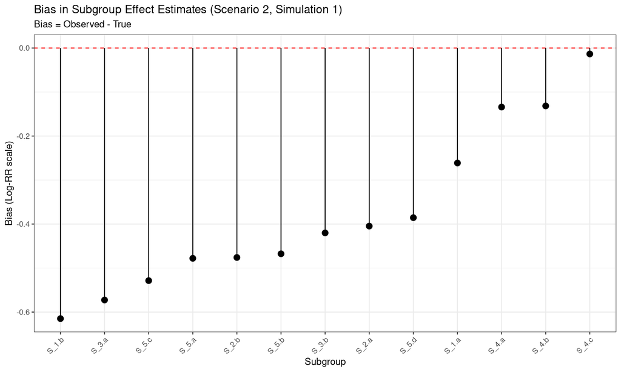

```r
if (truth_available) {

  library(ggplot2)

  # Create scatter plot
  ggplot(comparison_truth, aes(x = true, y = observed)) +
    geom_abline(intercept = 0, slope = 1, linetype = "dashed", color = "red") +
    geom_point(size = 3, alpha = 0.7) +
    geom_text(aes(label = subgroup), hjust = -0.1, vjust = -0.1, size = 2.5) +
    labs(
      title = "Observed vs True Treatment Effects (Scenario 2, Simulation 1)",
      subtitle = "Red line = perfect agreement",
      x = "True Log-RR",
      y = "Observed Log-RR (from subgroup models)"
    ) +
    theme_bw() +
    coord_fixed()

  # Create bias plot
  comparison_truth$subgroup <- factor(comparison_truth$subgroup,
                                       levels = comparison_truth$subgroup[order(comparison_truth$bias)])

  ggplot(comparison_truth, aes(x = subgroup, y = bias)) +
    geom_hline(yintercept = 0, linetype = "dashed", color = "red") +
    geom_point(size = 3) +
    geom_segment(aes(xend = subgroup, y = 0, yend = bias)) +
    labs(
      title = "Bias in Subgroup Effect Estimates (Scenario 2, Simulation 1)",
      subtitle = "Bias = Observed - True",
      x = "Subgroup",
      y = "Bias (Log-RR scale)"
    ) +
    theme_bw() +
    theme(axis.text.x = element_text(angle = 45, hjust = 1))

} else {
  cat("Truth data not available for visualization.\n")
}
```

## Conclusion

This document demonstrates:

1. **Population method**: Fits one model to all data, replicates estimate across subgroups
2. **Subgroup method**: Fits separate models within each subgroup
3. **Comparison**: Shows how much the subgroup estimates vary from the population estimate

The variation between subgroup and population estimates represents the heterogeneity in treatment effects across subgroups, plus sampling variability.